# Phase 1A: RNA-seq data analysis

David Amar, Archana Raja

Phase 1A raw data was preprocessed at the BIC using our pipeline, which was implemented according to the MOP. Here we present QC analyses performed on the output of the pipeline.

# Input data

Read the data from both sites - FPKMs, counts, and metadata (including the QC scores).

```r
# load required libraries
data_dir = "~/Desktop/MoTrPAC/data/pass_1a/rnaseq/"
library(data.table);library(DESeq2)
library(preprocessCore);library(ggplot2)
library(corrplot)
# load our helper functions
source("~/Desktop/repos/motrpac/tools/preprocessing_helper_functions.R")
source("~/Desktop/repos/motrpac/tools/association_analysis_functions.R")
source("~/Desktop/repos/motrpac/tools/gcp_functions.R")
source("~/Desktop/repos/motrpac/tools/enrichment_analysis_methods.R")
# This is pretty slow
source("~/Desktop/repos/motrpac/tools/rat_data.R")
```

```r
# Data paths
site2fpkm_path = list(
  stanford = "stanford/rsem_genes_fpkm_pass1a_batch1_Stanford.csv",
  sinai = "sinai/rsem_genes_fpkm_pass1a_batch1_Sinai.csv"
)
site2genecount_path = list(
  stanford = "stanford/rsem_genes_count_pass1a_batch1_Stanford.csv",
  sinai = "sinai/rsem_genes_count_pass1a_batch1_Sinai.csv"
)
site2fpkm_path = sapply(site2fpkm_path, function(x,y)paste(y,x,sep=""),y=data_dir)
site2genecount_path = sapply(site2genecount_path, function(x,y)paste(y,x,sep=""),y=data_dir)
# load the metadata of the samples
# this is a data frame called rnaseq_meta that contains
# the qc and sample metadata from both sites
load(paste(data_dir,"/rnaseq_meta.RData",sep=""))
rnaseq_meta$Tissue = tolower(rnaseq_meta$Tissue)
rnaseq_meta$Tissue = gsub(" powder","",rnaseq_meta$Tissue)
rnaseq_meta[rnaseq_meta=="N/A"] = NA
print("Number of samples flagged according to the MOP's thersholds:")
print(sum(rnaseq_meta$IsFlagged))
# Read the gene expression data in
site2fpkm = list()
site2counts = list()
for(site in names(site2fpkm_path)){
  currfpkm = fread(site2fpkm_path[[site]],header = T,
                   stringsAsFactors = F,data.table = F)
  rownames(currfpkm) = currfpkm[,1]
  currfpkm = currfpkm[,-1]
  site2fpkm[[site]] = currfpkm

  currcounts = fread(site2genecount_path[[site]],
                     header = T,stringsAsFactors = F,data.table = F)
  rownames(currcounts) = currcounts[,1]
  currcounts = currcounts[,-1]
  site2counts[[site]] = currcounts
}
# Metadata from DMAQC: use our merged data frame
merged_dmaqc_data =  load_from_bucket("merged_dmaqc_data.RData",
    "gs://bic_data_analysis/pass1a/pheno_dmaqc/",F)
```

```r
merged_dmaqc_data = merged_dmaqc_data[[1]]
merged_dmaqc_data$animal.key.timepoint[merged_dmaqc_data$animal.key.timepoint==-1
    & !merged_dmaqc_data$animal.key.is_control] = 0
table(merged_dmaqc_data$animal.key.timepoint)
# restrict the data frame to vial ids in our RNA-seq data
print("The following vial ids are not in the DMAQC data:")
print(setdiff(rownames(rnaseq_meta),merged_dmaqc_data$viallabel))
merged_dmaqc_data = merged_dmaqc_data[
    is.element(set=rownames(rnaseq_meta),merged_dmaqc_data$viallabel),]
rownames(merged_dmaqc_data) = as.character(merged_dmaqc_data$viallabel)
merged_dmaqc_data$tissue = merged_dmaqc_data$sampletypedescription
```

# Check the freeze times of the samples

```r
# look at time vs sex diffs in each tissue
tmpx = cbind(
  merged_dmaqc_data$labelid,
  merged_dmaqc_data$specimen.processing.sampletypedescription,
  merged_dmaqc_data$calculated.variables.time_complete_to_death_min,
  merged_dmaqc_data$calculated.variables.time_death_to_collect_min,
  merged_dmaqc_data$calculated.variables.time_collect_to_freeze_min,
  merged_dmaqc_data$animal.registration.sex,
  merged_dmaqc_data$animal.key.timepoint,
  merged_dmaqc_data$acute.test.weight
)
colnames(tmpx) = c(
  "labelid",
  "tissue",
  "time_complete_to_death",
  "time_death_to_collect",
  "time_collect_to_freeze",
  "sex",
  "timepoint",
  "weight"
)
tmpx = data.frame(tmpx)
for(j in 3:ncol(tmpx)){tmpx[[j]]=as.numeric(as.character(tmpx[[j]]))}
tissue_sex_pvals = c()
for(tissue in unique(tmpx$tissue)){
  df = tmpx[tmpx$tissue==tissue,]
  df = unique(df)
  print(dim(df))
  df$sex = df$sex-1

  if(any(is.na(df$time_collect_to_freeze))){next}
  if(length(unique(df$sex))<2){next}

  curr_lm = summary(glm(
    sex~time_collect_to_freeze + time_death_to_collect,data=df,
    family = "binomial"))
  pval = curr_lm$coefficients[2,4]
  beta = curr_lm$coefficients[2,2]

  tissue_sex_pvals = rbind(tissue_sex_pvals,
     c(curr_lm$coefficients[2,4],curr_lm$coefficients[3,4],nrow(df)))
  rownames(tissue_sex_pvals)[nrow(tissue_sex_pvals)] = tissue
  print(paste(tissue,beta,pval))
}
```

```
[1] 78  8
[1] "PaxGene RNA 0.790279848326075 0.817156550332186"
[1] 78  8
[1] "Gastrocnemius 1.35458596340903 1.56450409029915e-05"
[1] 78  8
[1] "Heart 0.487326620085408 0.34193164604345"
[1] 78  8
[1] "Kidney 0.322552892032564 0.418355934840108"
[1] 78  8
[1] "Brown Adipose 0.702405652020479 0.0232419073391203"
[1] 78  8
[1] "White Adipose 1.33435004344317 0.150985082849174"
[1] 78  8
[1] "Liver 2.03678223924658 0.230190793897815"
```

```r
tissue_log_ps = -log(tissue_sex_pvals[,1:2],base=10)
colnames(tissue_log_ps) = c(
  "collect_to_freeze","death_to_collect"
)
plt = barplot(t(tissue_log_ps),beside = T,xaxt="n",legend=T)
text(colMeans(plt), par("usr")[3], labels = rownames(tissue_log_ps),
     srt = 45, adj = c(1.1,1.1), xpd = T, cex=0.6)
```

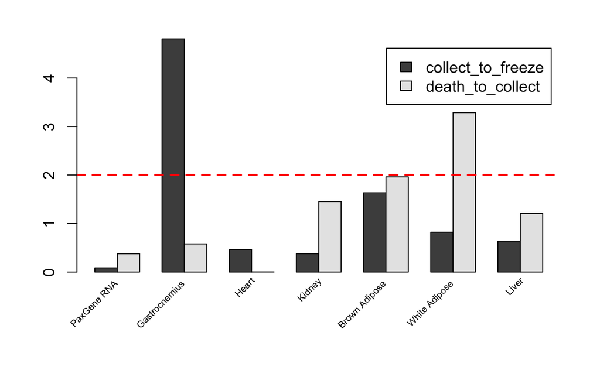

```r
abline(h = 2,lwd=2,col="red",lty=2)
```

# Data preprocessing and QC

We tested two ways to normalize the count data: (1) FPKM, and (2) factor normalized counts with and without variance stabilizing transformations (to accound for gene dispersion).

## FPKM data

```r
#' Takes an FPKM matrix, removes lowly expressed genes and log transform
#' the remaining matrix
#' @return A matrix of log transformed FPKMs
process_fpkm1 <-function(fpkm_matrix, intensity_threshold=0,intensity_pct=0.2){
  lowly_expressed_genes = rowSums(
    fpkm_matrix==intensity_threshold)/ncol(fpkm_matrix) > intensity_pct
  fpkm_matrix = fpkm_matrix[!lowly_expressed_genes,]
  fpkm_matrix = log(fpkm_matrix+1,base = 2)
  return(fpkm_matrix)
}
#' A wrapper for preprocessCore's quantile normalization.
#' Comment: we do not use this by default
run_quantile_normalization<-function(x){
  x = as.matrix(x)
  mode(x) = "numeric"
  newx = preprocessCore::normalize.quantiles.robust(x)
  rownames(newx) = rownames(x)
  colnames(newx) = colnames(x)
  return(newx)
}
# Process the FPKM matrix from each site separately
site_proc_fpkms = lapply(site2fpkm,process_fpkm1)
# Check the dimension of the reduced data
print("FPKM processing done for each site, matrix dim:")
print(sapply(site_proc_fpkms,dim))
# Get the shared genes
shared_genes = intersect(rownames(site_proc_fpkms[[1]]),
                         rownames(site_proc_fpkms[[2]]))
print("Number of shared genes that survive the filter above:")
print(length(shared_genes))
proc_fpkms = cbind(site_proc_fpkms[[1]][shared_genes,],
                   site_proc_fpkms[[2]][shared_genes,])
# QC: make sure the metadata and the expression matrix have the same sample id:
print("do we have the same samples in the expression and metadata matrices?")
print(all(colnames(proc_fpkms) %in% rownames(rnaseq_meta)))

# Run the PCA: try all genes first
fpkm_all = cbind(site2fpkm[[1]],site2fpkm[[2]])
fpkm_all = log(fpkm_all+1,base=2)
fpkm_pca = prcomp(t(fpkm_all))
fpkm_pcax = fpkm_pca$x
tissue_and_site = rnaseq_meta[rownames(fpkm_pcax),"Tissue"]
site_info = rnaseq_meta[rownames(fpkm_pcax),"site"]
tissue_and_site[grepl("gastroc",tissue_and_site) &
                  site_info == "stanford"] = "gastroc_stanford"
tissue_and_site[grepl("gastroc",tissue_and_site) &
                  site_info != "stanford"] = "gastroc_sinai"
df = data.frame(fpkm_pcax[,1:10],
                tissue = tissue_and_site,
                site = site_info)
scatterplot_colors =  scale_colour_manual(values=c(liver='#FF00FF',
         gastroc_stanford='#00cd00',
         gastroc_sinai='#00ee00',
         kidney='#a020f0',
         'brown adipose'='#ffa500',
         'white adipose'='#1e90ff',
         'paxgene rna'='#ff0000',
         heart='#40e0d0'))
ggplot(df,aes(x=PC1, y=PC2,shape=site,color=tissue)) +
  geom_point(size=2) + ggtitle("PCA using FPKMs: PCs 1 and 2") +
  theme(plot.title = element_text(hjust = 0.5)) +
  scatterplot_colors
ggplot(df,aes(x=PC4, y=PC3,shape=site, color=tissue)) +
  geom_point(size=2) + ggtitle("PCA using FPKMs: PCs 3 and 4") +
  theme(plot.title = element_text(hjust = 0.5)) +
  scatterplot_colors

# Rerun on the reduced matrix
fpkm_pca = prcomp(t(proc_fpkms),retx = T)
fpkm_pcax = fpkm_pca$x
fpkm_pca_proc = prcomp(t(fpkm_all),retx = T)
fpkm_pca_procx = fpkm_pca_proc$x
df = data.frame(fpkm_pca_procx[,1:10],
                tissue = tissue_and_site,
                site = site_info)
ggplot(df,aes(x=PC1, y=PC2,shape=site,color=tissue)) +
  geom_point(size=2) + ggtitle("PCA using FPKMs: PCs 1 and 2") +
  theme(plot.title = element_text(hjust = 0.5)) +
  scatterplot_colors
ggplot(df,aes(x=PC4, y=PC3,shape=site, color=tissue)) +
  geom_point(size=2) + ggtitle("PCA using FPKMs: PCs 3 and 4") +
  theme(plot.title = element_text(hjust = 0.5)) +
  scatterplot_colors
```

## Normalized counts

```r
# Pipeline 2: work with count data
# Combine the two count matrices
count_matrix = as.matrix(cbind(site2counts[[1]],site2counts[[2]]))
#' Use DESeq2 to estimate sample factors and gene dispersion
#' @return a DESeqDataSet
process_counts<-function(count_matrix,plotFactors=T){
  mode(count_matrix) = "integer"
  se <- SummarizedExperiment(count_matrix)
  dds <- DESeqDataSet(se, design = ~ 1 )
  #Estimate size factors
  dds <- estimateSizeFactors( dds )
  if(plotFactors){
      # Plot the size factors
    plot(sizeFactors(dds), colSums(counts(dds)),ylab="Library size",
         xlab = "DESeq estimated size factors")
    abline(lm(colSums(counts(dds)) ~ sizeFactors(dds) + 0))
  }
  dds <- estimateDispersions(dds)
  return(dds)
}

# Process the counts and normalize
dds = process_counts(count_matrix)
# Simple normalization and log transform
# The argument normalized equals true, divides each column by its size factor.
logcounts <- log2( counts(dds, normalized=TRUE) + 1 )
pc <- prcomp( t( logcounts ) )
counts_pcax1 = pc$x
# Try variance stabilizing transformation instead
vsd <- varianceStabilizingTransformation(dds)
pc2 <- prcomp( t( assay(vsd) ) )
counts_pcax2 = pc2$x
# PCA plots
df = data.frame(counts_pcax1[,1:10],
                tissue = rnaseq_meta[rownames(counts_pcax1),"Tissue"],
                site = rnaseq_meta[rownames(counts_pcax1),"site"])
ggplot(df,aes(x=PC1, y=PC2,shape=site, color=tissue)) +
  geom_point(size=2) + ggtitle("PCA using normalized counts") +
  theme(plot.title = element_text(hjust = 0.5))
df = data.frame(counts_pcax2[,1:10],
                tissue = rnaseq_meta[rownames(counts_pcax2),"Tissue"],
                site = rnaseq_meta[rownames(counts_pcax2),"site"])
ggplot(df,aes(x=PC1, y=PC2,shape=site, color=tissue)) +
  geom_point(size=2) + ggtitle("PCA using normalized counts (vsd)") +
  theme(plot.title = element_text(hjust = 0.5))
```

## Correlation between PCs and non-RNA variables

Here we take each tissue and analyze its samples. We quantile normalize the data and run PCA. For the top principal components (5) we compute their association with the RNA-seq qc scores or information collected about the rats. For the latter we use sex, weight, achieved distances, and shock time during the experiment. Note that all of these scores are highly correlated. Below we perform a simple Spearman correlation-based analysis. We can later recompute the associations after proper adjustments.

```r
# RNA-seq meta to correlate with genes/pcs
assay_cols_for_qc_analysis = c("RIN","reads","pct_GC","pct_rRNA","pct_globin",
                      "pct_umi_dup","median_5_3_bias","pct_trimmed_bases",
                      "pct_multimapped","pct_GC","pct_chrM")
# Animal information to correlate with genes/pcs
# FUTURE WORK: add site id and batch
animal_data_cols_for_qc_analysis = c(
  "acute.test.weight","animal.registration.sex","acute.test.distance",
  "acute.test.howlongshock_seconds","animal.key.timepoint",
  "calculated.variables.time_complete_to_death_min",
  "calculated.variables.time_death_to_collect_min",
  "calculated.variables.time_collect_to_freeze_min"
  )
# Labels for separating the data by site and tissue
rnaseq_meta_batchs = unique(rnaseq_meta[,c("GET_site","Tissue")])

qc_scores_results = c()
animal_data_results = c()
p_thr = 0.001
for(i in 1:nrow(rnaseq_meta_batchs)){
  curr_site = rnaseq_meta_batchs[i,1]
  curr_tissue = rnaseq_meta_batchs[i,2]
  curr_samples = as.character(rnaseq_meta$vial_label[rnaseq_meta$GET_site==curr_site &
                                          rnaseq_meta$Tissue==curr_tissue])
  # For rat data, take samples whose label id starts with "9"
  curr_samples = curr_samples[grepl("^9",curr_samples)]
  curr_data = process_fpkm1(fpkm_all[,curr_samples])
  curr_data = run_quantile_normalization(curr_data)
  curr_pca = prcomp(t(curr_data))
  curr_pcax = curr_pca$x[,1:5]
  explained_var = summary(curr_pca)[["importance"]][3,5]
  curr_meta1 = rnaseq_meta[curr_samples,assay_cols_for_qc_analysis]
  corrs = cor(curr_pcax,curr_meta1,method="spearman")
  corrsp = pairwise_eval(curr_pcax,curr_meta1,func=cor.test,f="p.value",method="spearman")
  for(i in 1:nrow(corrsp)){
    for(j in 1:ncol(corrsp)){
      if(corrsp[i,j]>p_thr){next}
      qc_scores_results = rbind(qc_scores_results,
            c(curr_tissue,curr_site,
              rownames(corrsp)[i],colnames(corrsp)[j],corrs[i,j],corrsp[i,j])
            )
    }
  }
  colnames(qc_scores_results) = c("Tissue","CAS_site","PC",
                                  "qc_metric","rho(spearman)","p-value")

  curr_meta2 = merged_dmaqc_data[curr_samples,animal_data_cols_for_qc_analysis]
  # Animal analysis: for correlations consider rats with distance >0
  training_rats = curr_meta2$acute.test.distance > 0
  training_rats_x = curr_pcax[training_rats,]
  training_rats_meta = curr_meta2[training_rats,]
  corrs2 = cor(training_rats_x,training_rats_meta,method="spearman")
  corrsp2 = pairwise_eval(training_rats_x,
                          training_rats_meta,func=cor.test,f="p.value",method="spearman")
  colnames(corrs2) = sapply(colnames(corrs2),function(x)strsplit(x,split='\\.')[[1]][3])
  for(i in 1:nrow(corrsp2)){
    for(j in 1:ncol(corrsp2)){
      if(corrsp2[i,j]>p_thr){next}
      animal_data_results = rbind(animal_data_results,
            c(curr_tissue,curr_site,
              rownames(corrsp2)[i],colnames(corrsp2)[j],corrs2[i,j],corrsp2[i,j])
            )
    }
  }
  colnames(animal_data_results) = c("Tissue","CAS_site","PC",
                                  "variable","rho(spearman)","p-value")

  # In case we want a linear test for association
  # corrsp2 = pairwise_eval(as.data.frame(curr_pcax),
  #   curr_meta2,func=linear_association_analysis,f="pval")

  # Add some plots for selected tissues
  if(grepl("white adipose",curr_tissue) ||
     grepl("heart|gastro",curr_tissue,ignore.case = T)){
      main = paste(curr_tissue,curr_site,
                   paste("(",format(explained_var,digits = 2),")",sep=""))
      corrplot(corrs,p.mat = corrsp,
               sig.level = 0.001,title = main,mar = c(3,3,3,3))
      corrplot(corrs2,p.mat = corrsp2,
               sig.level = 0.001,title = main,mar = c(3,3,3,3))
  }
}

write.table(qc_scores_results,sep="\t",quote=F,row.names = F)
write.table(animal_data_results,sep="\t",quote=F,row.names = F)
```

## $\pi_1$ estimates

```r
assay_cols_for_qc_analysis = c("pct_GC","pct_globin","pct_multimapped")
# Animal information to correlate with genes/pcs
# FUTURE WORK: add site id and batch
animal_data_cols_for_qc_analysis = c(
  "animal.registration.sex",
  "acute.test.distance",
  "animal.key.timepoint",
  "calculated.variables.time_death_to_collect_min",
  "calculated.variables.time_collect_to_freeze_min"
)

library(limma)
dataset2pi1s = c()
dataset2pvals = list()
for(i in 1:nrow(rnaseq_meta_batchs)){
  curr_site = rnaseq_meta_batchs[i,1]
  curr_tissue = rnaseq_meta_batchs[i,2]
  curr_samples = as.character(rnaseq_meta$vial_label[rnaseq_meta$GET_site==curr_site &
                                          rnaseq_meta$Tissue==curr_tissue])
  # For rat data, take samples whose label id starts with "9"
  curr_samples = curr_samples[grepl("^9",curr_samples)]
  curr_data = process_fpkm1(fpkm_all[,curr_samples])
  curr_data = run_quantile_normalization(curr_data)
  curr_meta1 = rnaseq_meta[curr_samples,assay_cols_for_qc_analysis]
  curr_meta2 = merged_dmaqc_data[curr_samples,animal_data_cols_for_qc_analysis]

  curr_meta = cbind(curr_meta1,curr_meta2)
  pi1_meta = c()
  nsamp=2000
  pvals = list()
  for(j in 1:ncol(curr_meta)){
    samp = sample(1:nrow(curr_data))[1:nsamp]
    res = apply(curr_data[samp,],1,linear_association_analysis,y=curr_meta[,j])
    if(class(res)=="matrix"){
      res_ps = res[1,]
    }
    else{
      res_ps = sapply(res, function(x)x[1])
    }
    hist(res_ps,main = paste(colnames(curr_meta)[j],curr_tissue,sep=","))
    pi1 = 1 - propTrueNull(res_ps,nbins = 20)
    pi1_meta[colnames(curr_meta)[j]] = pi1
    pvals[[colnames(curr_meta)[j]]] = res_ps
  }

  dataset2pi1s = rbind(dataset2pi1s,pi1_meta)
  currname = paste(curr_tissue,curr_site,sep=",")
  rownames(dataset2pi1s)[nrow(dataset2pi1s)] = currname
  dataset2pvals[[currname]] = pvals
  # Add some plots for selected tissues
  if(grepl("white adipose",curr_tissue) ||
     grepl("heart|gastro",curr_tissue,ignore.case = T)){
  }
}
```

# Differential abundance analysis (FPKM)

## Create the datasets and save

```r
# Prepare the data for the analysis
Z_cols = c("RIN","reads","pct_GC","pct_rRNA","pct_globin",
                      "pct_umi_dup","median_5_3_bias","pct_trimmed_bases",
                      "pct_multimapped","pct_GC","pct_chrM")
clinical_cols = c("animal.registration.sex","animal.key.timepoint",
                  "animal.key.is_control","acute.test.distance",
                  "acute.test.weight",
                  "calculated.variables.frozetime_after_acute",
                  "calculated.variables.edta_coll_time",
                  "bid","pid")
rnaseq_data_for_difftests = list()
rnaseq_meta_batchs = unique(rnaseq_meta[,c("GET_site","Tissue")])
for(i in 1:nrow(rnaseq_meta_batchs)){
  curr_site = rnaseq_meta_batchs[i,1]
  curr_tissue = rnaseq_meta_batchs[i,2]
  curr_samples = as.character(
    rnaseq_meta$vial_label[rnaseq_meta$GET_site==curr_site &
    rnaseq_meta$Tissue==curr_tissue])
  # For rat data, take samples whose label id starts with "9"
  curr_samples = curr_samples[grepl("^9",curr_samples)]
  curr_data = process_fpkm1(fpkm_all[,curr_samples])
  curr_data = run_quantile_normalization(curr_data)
  curr_data = as.matrix(curr_data)
  curr_meta1 = rnaseq_meta[curr_samples,Z_cols]
  curr_meta2 = merged_dmaqc_data[curr_samples,clinical_cols]
  non_control_inds = (!curr_meta2$animal.key.is_control) |
    (curr_meta2$animal.key.is_control & curr_meta2$animal.key.timepoint ==
       min(curr_meta2$animal.key.timepoint))
  curr_name = paste(curr_tissue,curr_site,sep=",")
  rnaseq_data_for_difftests[[curr_name]] = list(fpkms = curr_data,
      pipeline_meta = curr_meta1,dmaqc_meta = curr_meta2,
      non_control_inds=non_control_inds)
}
save_to_bucket(rnaseq_data_for_difftests,file = "rnaseq_data_for_difftests.RData",
               bucket = "gs://bic_data_analysis/pass1a/rnaseq/")
```

In this analysis we use simple linear regression to model the log fold changes. Here we perfom a simple analysis excluding the control groups (sampled in two time points only). Assume that we are analyzing a specific gene with a gene expression pattern $x$ in a given tissue. We use the following covatiates in the model: (1) $y_{sex}$ - sex, (2) $lt_i$ - time, linear trend, (3) $qt_i$ - time, quadratic trend, (4) $y_d$ - distance acheived by the rat during the acute test, and (5) $Z$ - technical variables. That is:
$$x_i = \beta_0 + \beta_{sex}*y_{sex}+\beta_l*lt_i + \beta_q*qt_i + \beta_d*y_d + \bf{\beta_z^TZ_{i,*}}$$
.

Here is the code for this analysis:

```r
# store all betas and their p-values
tissue2diff_analysis_results = list()
for(curr_name in names(rnaseq_data_for_difftests)){
  curr_data = rnaseq_data_for_difftests[[curr_name]]$fpkms
  curr_meta1 = rnaseq_data_for_difftests[[curr_name]]$pipeline_meta
  curr_meta2 = rnaseq_data_for_difftests[[curr_name]]$dmaqc_meta
  # to exclude the controls before the analysis:
  non_control_inds = rnaseq_data_for_difftests[[curr_name]]$non_control_inds
  # Define the formula
  tp_poly = poly(curr_meta2$animal.key.timepoint,degree = 2)
  colnames(tp_poly) = c("time.linear","time.quad")
  X = cbind(curr_meta2,curr_meta1,tp_poly)
  form = y ~ time.linear + time.quad +
    animal.registration.sex + pct_multimapped + acute.test.distance +
    pct_umi_dup + median_5_3_bias + pct_rRNA
  # Run the tests
  lm_results = t(apply(curr_data[,non_control_inds],1,
                       lm_wrapper_for_diff_abundance_analysis,
                       x=X[non_control_inds,],form=form))
  # Save the results and the analysis input into a single object
  tissue2diff_analysis_results[[curr_name]] = list(
    diff_res = lm_results,ge_data = curr_data,
    X = X,form=form,
    non_control_inds = non_control_inds
  )
}

# Save the results to our google bucket

save(tissue2diff_analysis_results,
       file="tissue2diff_analysis_results.RData")
system(paste("~/google-cloud-sdk/bin/gsutil", "cp tissue2diff_analysis_results.RData",
             "gs://bic_data_analysis/pass1a/rnaseq/"))
system("rm tissue2diff_analysis_results.RData")

# Add simple ANOVA
tissue2diff_analysis_results_anova = list()
tissue2diff_analysis_results_kw = list()
for(curr_name in names(rnaseq_data_for_difftests)){
  curr_data = rnaseq_data_for_difftests[[curr_name]]$fpkms
  curr_meta1 = rnaseq_data_for_difftests[[curr_name]]$pipeline_meta
  curr_meta2 = rnaseq_data_for_difftests[[curr_name]]$dmaqc_meta
  # to exclude the controls before the analysis:
  non_control_inds = rnaseq_data_for_difftests[[curr_name]]$non_control_inds
  y = curr_meta2$animal.key.timepoint[non_control_inds]
  curr_data = curr_data[,non_control_inds]

  curr_res1 = apply(curr_data,1,compare_multigroup_means,y = y)
  curr_res2 = apply(curr_data,1,compare_multigroup_means,
                    y = y,f = kruskal.test)

  tissue2diff_analysis_results_anova[[curr_name]] = curr_res1
  tissue2diff_analysis_results_kw[[curr_name]] = curr_res2
}
save(tissue2diff_analysis_results_anova,tissue2diff_analysis_results_kw,
       file="tissue2diff_analysis_results_simple_univariate.RData")
system(paste("~/google-cloud-sdk/bin/gsutil",
             "cp tissue2diff_analysis_results_simple_univariate.RData",
             "gs://bic_data_analysis/pass1a/rnaseq/"))
```

## T-tests and mediation analysis for sex vs weight

```r
library(mediation)
run_sex_weight_mediation<-function(x,s,w){
  m1 = lm(w~s)
  m2 = lm(x~s+w)
  med.out = mediate(m1,m2,treat="s",mediator="w",boot=T,
                    robustSE = TRUE, sims = 100)
  med.out = summary(med.out)
  med.out[c("d0.p","d1.p")]
  res = unlist(med.out[c("d0","d0.p","z0","z0.p","n0","tau.coef","tau.p")])
  names(res) = c("med_effect","med_effect_pvalue",
                 "direct_effec","direct_effect_pvalue",
                 "prop_mediated","total_effect","tot_effect_p")
  return(res)
}

t_tests_results = list()
for(curr_name in names(rnaseq_data_for_difftests)){
  curr_data = rnaseq_data_for_difftests[[curr_name]]$fpkms
  curr_meta1 = rnaseq_data_for_difftests[[curr_name]]$pipeline_meta
  curr_meta2 = rnaseq_data_for_difftests[[curr_name]]$dmaqc_meta
  # to exclude the controls before the analysis:
  non_control_inds = rnaseq_data_for_difftests[[curr_name]]$non_control_inds
  y = curr_meta2$animal.key.timepoint
  z = curr_meta2$animal.key.is_control

  controls_data = curr_data[,z & y==min(y)]
  mean_control = rowMeans(controls_data)
  curr_data = curr_data[,!z]
  y = y[!z]
  for(tp in unique(y)){
    x = curr_data[,y==tp]
    x_ttest = cbind(x,controls_data)
    g = curr_meta2[colnames(x_ttest),]$animal.key.is_control
    ttest_res = t(apply(x_ttest,1,compare_two_groups,y = g))
    fchange = ttest_res[,1]-ttest_res[,2]
    hist(ttest_res[,3])
    ttest_res = cbind(ttest_res,fchange)
    colnames(ttest_res) = c("mean1","mean2","p","fchange")
    curr_entry_name = paste(curr_name,tp,sep=",")
    t_tests_results[[curr_entry_name]] = ttest_res
  }
}

mediation_results = list()
for(curr_name in names(rnaseq_data_for_difftests)){
  curr_data = rnaseq_data_for_difftests[[curr_name]]$fpkms
  curr_meta1 = rnaseq_data_for_difftests[[curr_name]]$pipeline_meta
  curr_meta2 = rnaseq_data_for_difftests[[curr_name]]$dmaqc_meta
  # to exclude the controls before the analysis:
  non_control_inds = rnaseq_data_for_difftests[[curr_name]]$non_control_inds
  y = curr_meta2$animal.key.timepoint
  z = curr_meta2$animal.key.is_control

  controls_data = curr_data[,z & y==min(y)]
  mean_control = rowMeans(controls_data)
  curr_data = curr_data[,!z]
  y = y[!z]

  regression_res = tissue2diff_analysis_results[[curr_name]]
  regression_res = as.data.frame(regression_res$diff_res)
  p1 = regression_res$`pval;animal.registration.sex`
  p2 = regression_res$`pval;time.quad`
  curr_genes = rownames(regression_res)[
    p.adjust(p1,method="fdr") < 0.1 &
      p.adjust(p2,method="fdr") < 0.1
  ]

  for(tp in unique(y)){
    curr_entry_name = paste(curr_name,tp,sep=",")
    x = curr_data[,y==tp]
    ttest_res = t_tests_results[[curr_entry_name]]
    fchange = ttest_res[,"fchange"]

    # prepare data for the mediation analysis
    for(j in 1:ncol(x)){x[,j] = x[,j]-mean_control}
    s = curr_meta2[colnames(x),]$animal.registration.sex
    s = s-1
    w = curr_meta2[colnames(x),]$acute.test.weight
    # select rows for the medition analysis
    inds = curr_genes
    print(table(inds))
    mediation_analysis_res = apply(x[inds,],1,run_sex_weight_mediation,s=s,w=w)
    mediation_analysis_res = t(mediation_analysis_res)
    mediation_results[[curr_entry_name]] = mediation_analysis_res
  }
}

save(t_tests_results,mediation_results,
       file="tissue2diff_ttest_and_mediation.RData")
system(paste("~/google-cloud-sdk/bin/gsutil",
             "cp tissue2diff_ttest_and_mediation.RData",
             "gs://bic_data_analysis/pass1a/rnaseq/"))
system("rm tissue2diff_ttest_and_mediation.RData")
```

## QC plots

We next inspect the results of the analysis. At a first step, we inspect the p-value distributions of the time-associated differential analysis.

```r
# load precomputed data and results
tissue2diff_analysis_results = load_from_bucket(
  "tissue2diff_analysis_results.RData",
  "gs://bic_data_analysis/pass1a/rnaseq/"
)[[1]]
one_way_results = load_from_bucket(
  "tissue2diff_analysis_results_simple_univariate.RData",
  "gs://bic_data_analysis/pass1a/rnaseq/"
)
tissue2diff_analysis_results_anova = one_way_results[[
  "tissue2diff_analysis_results_anova"
]]
tissue2diff_analysis_results_kw = one_way_results[[
  "tissue2diff_analysis_results_kw"
]]
rnaseq_data_for_difftests = load_from_bucket(
  "rnaseq_data_for_difftests.RData",
  "gs://bic_data_analysis/pass1a/rnaseq/"
)[[1]]
pairwise_tests_results = load_from_bucket(
  "tissue2diff_ttest_and_mediation.RData",
  "gs://bic_data_analysis/pass1a/rnaseq/"
)
t_tests_results = pairwise_tests_results[["t_tests_results"]]
mediation_results = pairwise_tests_results[["mediation_results"]]

# Plot p-values
print("number of analyzed genes in each tissue:")
print(sapply(tissue2diff_analysis_results,function(x)dim(x[[1]])))
par(mfrow=c(1,3))
for(curr_name in names(tissue2diff_analysis_results)){
  lm_results = tissue2diff_analysis_results[[curr_name]][[1]]
  distance_col = grepl("distance",colnames(lm_results)) &
    grepl("pval",colnames(lm_results))
  sex_col = grepl("sex",colnames(lm_results)) &
    grepl("pval",colnames(lm_results))
  time_col = grepl("time.q",colnames(lm_results)) &
    grepl("pval",colnames(lm_results))
  hist(lm_results[,time_col],
       main=paste(curr_name,"linear trend"),xlab="P-value",
       cex.main=1)
  hist(lm_results[,distance_col],
       main=paste(curr_name,"distance"),xlab="P-value",
       cex.main = 1)
  hist(lm_results[,sex_col],
       main=paste(curr_name,"sex"),xlab="P-value",
       cex.main = 1)
}
```

## T-test results: analysis

Here we use empirical Bayes methods to quantify the number of differential genes in each analysis.

```r
all_ttest_pvals = lapply(t_tests_results,function(x)x[,3])
all_pvals = unname(unlist(all_ttest_pvals))
all_qvals = p.adjust(all_pvals,method="BY")
pval_thr = max(all_pvals[all_qvals<0.1])
all_ttest_fcs = lapply(t_tests_results,function(x)x[,4])

merge_matrix<-function(l,missing_val = 1){
  objs = unique(unname(unlist(sapply(l,names))))
  m = matrix(missing_val,nrow=length(objs),ncol=length(l),
             dimnames = list(objs,names(l)))
  for(j in 1:length(l)){
    v = l[[j]]
    m[names(v),j] = v
  }
  return(m)
}

all_ttest_pvals = merge_matrix(all_ttest_pvals)
all_ttest_fcs = merge_matrix(all_ttest_fcs,0)
corrplot(cor(all_ttest_pvals),tl.cex = 0.5)
corrplot(cor(all_ttest_fcs),tl.cex = 0.5,order="hclust")

hist(all_ttest_pvals)
colSums(all_ttest_pvals<pval_thr)

# Network prop or simple distances
library(dnet);library(foreach);library(doParallel);library(parallel)
g = igraph::graph_from_edgelist(rat_ppi_entrez)
nodes = names(V(g))
res_mat = all_ttest_pvals < pval_thr
rownames(res_mat) = rat_ensembl2entrez_simple[rownames(res_mat)]
to_rem = is.na(rownames(res_mat)) | !is.element(rownames(res_mat),set=nodes)
res_mat = res_mat[!to_rem,]
currgenes = rownames(res_mat)
res_mat = apply(res_mat,2,function(x,y)tapply(x,INDEX = y,FUN = sum),y=currgenes)
mode(res_mat) = "numeric"
res_mat = as.data.frame(res_mat,check.names = F)
g = igraph::subgraph(g,rownames(res_mat))
res_mat = res_mat[names(V(g)),]

prop_res = dRWRpipeline(res_mat,g,normalise="none",
                restart=0.5, parallel=FALSE,method="direct")
prop_res1 = as.matrix(prop_res$ratio)
rownames(prop_res1) = colnames(res_mat)
colnames(prop_res1) = colnames(res_mat)
dim(prop_res1)
hist(prop_res1)
corrplot(prop_res1,tl.cex = 0.5,order="hclust",is.corr=F)

# Direct computation of propagations or distances
prop_matrix = c()
distance_matrix = c()
prop_results = dRWR(g,normalise = "none",setSeeds = res_mat,restart = 0.5)
for(nn1 in colnames(res_mat)){
  v = as.matrix(res_mat[,nn1])
  print(table(v))
  rownames(v) = rownames(res_mat)
  curr_prop = dRWR(g,normalise = "none",setSeeds = v,restart = 0.5)
  curr_prop = as.matrix(curr_prop)
  rownames(curr_prop) = names(V(g))
  prop_results = cbind(prop_results,curr_prop[,1])
  new_scores = c()
  for(nn2 in colnames(res_mat)){
    set2 = rownames(res_mat)[res_mat[,nn2]>0]
    new_scores[nn2] = sum(curr_prop[set2,1])
  }
  prop_matrix = rbind(prop_matrix,new_scores)
  rownames(prop_matrix)[nrow(prop_matrix)] = nn1
}
corrplot(prop_matrix,is.corr = F)


# # An alternative: create an integrated graph first and then propagate
# merged_net = igraph::as_edgelist(g)
# for(nn in colnames(res_mat)){
#   curr_genes = rownames(res_mat)[res_mat[,nn]>0]
#   curr_edges = cbind(rep(nn,length(curr_genes)),curr_genes)
#   print(dim(curr_edges))
#   merged_net = rbind(merged_net,curr_edges)
# }
# merged_g = igraph::graph_from_edgelist(merged_net,directed = F)
# nodes = names(V(merged_g))
# seeds = matrix(0,nrow=length(nodes),ncol=ncol(res_mat))
# rownames(seeds) = nodes
# colnames(seeds) = colnames(res_mat)
# for(nn in names(res_mat)){seeds[nn,nn]=sum(res_mat[,nn])}
# prop_res = dRWR(merged_g,"laplacian",seeds,
#                 normalise.affinity.matrix = "quantile",
#                 restart = 0.5)
# prop_res = as.matrix(prop_res)
# colnames(prop_res) = colnames(seeds)
# rownames(prop_res) = rownames(seeds)
# prop_res = prop_res[colnames(res_mat),colnames(res_mat)]
# diag(prop_res) = 0
# for(i in 1:nrow(prop_res)){
#   prop_res[i,] = prop_res[i,]/(sum(prop_res[i,]))
# }
#
# corrplot(prop_res,is.corr = F,tl.cex = 0.5,order="hclust")
# corrplot(prop_res,is.corr = F)
```

We next extract the fold change and p-value matrices and compare the tissues, with and without network propagation.

## Enrichment analysis and interpretation

```r
library(org.Rn.eg.db)
res = t_tests_results$`brown adipose,Stanford,4`
geneset = rownames(res)[p.adjust(res[,3])<0.1]
topgo_res = run_topgo_enrichment_fisher(geneset,rownames(res),
    mapping = "org.Rn.eg.db",ID="ensembl")
extract_top_go_results(topgo_res,qval = 0.01,maxsize = 200)

med_res = mediation_results$`gastrocnemius,MSSM,4`
colnames(med_res)
med_res[,2] = pmax(med_res[,2],0.0001)
med_res[,7] = pmax(med_res[,7],0.0001)
weight_assoc_genes = p.adjust(med_res[,2],method="fdr")<0.1
sex_assoc_genes = p.adjust(med_res[,7],method="fdr")<0.1
table(weight_assoc_genes,sex_assoc_genes)
table(weight_assoc_genes)

geneset = rownames(med_res)[weight_assoc_genes]
geneset = names(which(sex_assoc_genes))
topgo_res = run_topgo_enrichment_fisher(
  geneset,rownames(res),mapping = "org.Rn.eg.db",ID="ensembl")
extract_top_go_results(topgo_res,qval = 1,maxsize = 2000)

dataset = rnaseq_data_for_difftests$`gastrocnemius,MSSM`
X = dataset$fpkms[geneset,]
cols = as.factor(dataset$dmaqc_meta$animal.key.timepoint)
boxplot(X[2,]~dataset$dmaqc_meta$animal.registration.sex)
inds = dataset$dmaqc_meta$animal.registration.sex==1
plot(X[2,inds],dataset$dmaqc_meta$acute.test.weight[inds])
```

# Site comparison using the Gastrocnemius samples

## Simple comparison of the differential analysis results

As a first, simple analysis we load the differential analysis results and compare Stanford and Sinai.

```r
# Load the data, get the shared genes
load(paste(getwd(),"tissue2diff_analysis_results.RData",sep="/"))
res_stanford = tissue2diff_analysis_results[["gastrocnemius,Stanford"]][[1]]
res_mssm = tissue2diff_analysis_results[["gastrocnemius,MSSM"]][[1]]
shared_genes = intersect(rownames(res_stanford),rownames(res_mssm))
print("Loaded the differential analysis results. The number of shared genes in the Stanford and Sinai results is:")
print(length(shared_genes))
```

Compare all statistics of the differential analysis. Here we expect a low correlation between the statistics of technical variables and higher correlation for clinical variables (e.g., time).

```r
res_stanford = res_stanford[shared_genes,]
res_mssm = res_mssm[shared_genes,]
stanford_vs_sinai_diff_comparison_rho = diag(cor(res_mssm,res_stanford,method="spearman"))
p<-ggplot(data=data.frame(
          rho=stanford_vs_sinai_diff_comparison_rho,
          statistic = names(stanford_vs_sinai_diff_comparison_rho)),
          aes(x=statistic,y=rho)) + geom_bar(stat = "identity")
p + coord_flip()
```

Finally, compare the genes by looking at their p-values.

```r
res_stanford = res_stanford[shared_genes,]
res_mssm = res_mssm[shared_genes,]
par(mfrow=c(1,2))
rho_linear = cor(-log(res_stanford[,"pval;time.linear"],10),
                 -log(res_mssm[,"pval;time.linear"],10))
plot(x = -log(res_stanford[,"pval;time.linear"],10),
     y = -log(res_mssm[,"pval;time.linear"],10),
     xlab="Stanford",ylab="Sinai",pch=20,cex=0.5,
     main="Linear time trend")
abline(0,1,lty=2,lwd=3)
plot(x = -log(res_stanford[,"pval;time.quad"],10),
     y = -log(res_mssm[,"pval;time.quad"],10),
     xlab="Stanford",ylab="Sinai",pch=20,cex=0.5,
     main="Quad time trend")
abline(0,1,lty=2,lwd=3)
```

## Load the data

```r
# tissue vector - used below for getting the subset of
# Gastrocnemius samples
tissue = rnaseq_meta$Tissue
names(tissue) = rownames(rnaseq_meta)
# get the Gastrocnemius samples from each site
Gastrocnemius_fpkm = lapply(site2fpkm,
    function(x,y)x[,grepl("Gastrocnemius",y[colnames(x)],ignore.case = T)],y=tissue)
print("Gastrocnemius samples, data dim:")
print(sapply(Gastrocnemius_fpkm,dim))
# Process the FPKM data matrix from each site separately
Gastrocnemius_fpkm_processed = lapply(Gastrocnemius_fpkm,process_fpkm1)
print("Filtered FPKM data (separately for each site):")
print(sapply(Gastrocnemius_fpkm_processed,dim))
shared_genes = intersect(rownames(Gastrocnemius_fpkm_processed[[1]]),
                         rownames(Gastrocnemius_fpkm_processed[[2]]))
print("Number of shared genes that survive the filter above:")
print(length(shared_genes))
# Merge the datasets, store in a single data frame
Gastrocnemius_fpkm_mat = cbind(Gastrocnemius_fpkm_processed[[1]][shared_genes,],
                        Gastrocnemius_fpkm_processed[[2]][shared_genes,])

# Analysis of the metadata
Gastrocnemius_metadata = rnaseq_meta[colnames(Gastrocnemius_fpkm_mat),]
# We by default keep the vial sample id, which is different even if
# the biospecimen id is the same.
# This vector keeps the BID+PIDs
sample_id = paste(Gastrocnemius_metadata$BID,Gastrocnemius_metadata$PID,sep=";")
names(sample_id) = rownames(Gastrocnemius_metadata)
print("Do we have a copy from each site?")
all(table(sample_id)==2) # QC: make sure we have two copies for each id
# Reorder the data by the site and sample id
Gastrocnemius_metadata = Gastrocnemius_metadata[order(Gastrocnemius_metadata$site,sample_id),]
sample_id = sample_id[rownames(Gastrocnemius_metadata)]
```

## QC scores: site comparison

Here we compare the two sites by taking all numeric qc scores. We compare the two sites using a paired non-parametric test (Wilcoxon).

```r
metadata2site_pval = c()
site_ind = Gastrocnemius_metadata$site==Gastrocnemius_metadata$site[1]
# We go over all numeric columns in the metadata matrix and use
# a paired Wilcoxon test to estimate site differences
for(col in names(Gastrocnemius_metadata)){
  x = Gastrocnemius_metadata[[col]]
  if(! mode(x)=="numeric"){next}
  # data are ordered by site and sample id, which keeps the correct
  # order for the paired test
  x1 = x[site_ind];x2 = x[!site_ind] # define the two vectors
  if(!is.numeric(x1) || !is.numeric(x2)){next}
  sd1 = sd(x1,na.rm = T);sd2=sd(x2,na.rm = T)
  if(is.na(sd1)||is.na(sd2)){next}
  if(sd1==0 || sd2==0){next}
  # Need to try, some numeric columns are constants or have NAs
  metadata2site_pval[col] = wilcox.test(x1,x2,paired=T)$p.value
}
# Take the top 30 significant columns
selected_qc_comparisons = sort(metadata2site_pval)[1:30]
# Some of the columns are not informative (e.g., date)
# Take the "pct_" columns and print the p-values
print("Top pct_ qc scores that differ between sites:")
print(selected_qc_comparisons[grepl("pct_",names(selected_qc_comparisons))])
```

```r
# Comparison 1: selected qc scores
par(mfrow=c(2,2))
boxplot(pct_umi_dup~site,data=Gastrocnemius_metadata,main="% UMI dup")
boxplot(r_260_230~site,data=Gastrocnemius_metadata,main = "260/230")
abline(h = 1.8,lty=2,col="red")
boxplot(pct_rRNA~site,data=Gastrocnemius_metadata,main="%rRNA")
abline(h = 20,lty=2,col="red")
boxplot(pct_globin~site,data=Gastrocnemius_metadata,main="%Globin")
```

## FPKM data comparison

We next compare the sites by looking at the boxplot of the sample data (after removing lowly expressed genes).

```r
# Comparison 2: boxplots
#' Helper function to get a color set by a discrete vector
get_cols_vector_from_names<-function(v,pl_func = topo.colors){
  v = as.character(v)
  vals = unique(v)
  cols = pl_func(length(vals))
  names(cols) = vals
  newv = cols[v]
  return(list(newv,cols))
}
currcols = get_cols_vector_from_names(
  rnaseq_meta[colnames(Gastrocnemius_fpkm_mat),"site"],rainbow)
# Select a set of samples for the plot (too many samples otherwise)
inds_for_boxplot = c(1:10,81:90)
x_for_boxplot = Gastrocnemius_fpkm_mat[,inds_for_boxplot]
boxplot(x_for_boxplot,names=rep("",ncol(x_for_boxplot)),
        col=currcols[[1]][inds_for_boxplot],
        ylim = c(0,20),ylab="log2 FPKM") # extend lim to have room for legend
legend(x="top",names(currcols[[2]]),fill=currcols[[2]])
```

```r
# Comparison 3: PCA
# Attempt 1: Take the FPKM data and run the PCA
Gastrocnemius_fpkm_pca = prcomp(t(Gastrocnemius_fpkm_mat))
Gastrocnemius_fpkm_pcax = Gastrocnemius_fpkm_pca$x
df = data.frame(Gastrocnemius_fpkm_pcax[,1:10],
                shape=Gastrocnemius_metadata$site, site=Gastrocnemius_metadata$site,
                sample = sample_id[rownames(Gastrocnemius_fpkm_pcax)],
                sex = as.factor(
                  merged_dmaqc_data[rownames(Gastrocnemius_metadata),"animal.registration.sex"]
                ))
df = df[order(df$sample),]
# Add lines between matching samples (i.e., same sample, different site)
ggplot(df,aes(x=PC1, y=PC2, shape=sex, color=site,group=sample)) +
  geom_point(size=2) + geom_path(size=0.02,color="blue") +
  ggtitle("PCs 1 and 2: Gastrocnemius samples") +
  theme(plot.title = element_text(hjust = 0.5))
# Retry - quantile normalization before PCA (slightly cleaner)
Gastrocnemius_fpkm_mat_q = run_quantile_normalization(Gastrocnemius_fpkm_mat)
Gastrocnemius_fpkm_pca = prcomp(t(Gastrocnemius_fpkm_mat_q))
Gastrocnemius_fpkm_pcax = Gastrocnemius_fpkm_pca$x
df = data.frame(Gastrocnemius_fpkm_pcax[,1:10],
                shape=Gastrocnemius_metadata$site, site=Gastrocnemius_metadata$site,
                sample = sample_id[rownames(Gastrocnemius_fpkm_pcax)],
                sex = as.factor(
                  merged_dmaqc_data[rownames(Gastrocnemius_metadata),"animal.registration.sex"]
                ))
df = df[order(df$sample),]
# Add lines between matching samples (i.e., same sample, different site)
ggplot(df,aes(x=PC1, y=PC2, shape=sex, color=site,group=sample)) +
  geom_point(size=2) + geom_path(size=0.02,color="blue") +
  ggtitle("PCs 1 and 2: Gastrocnemius samples") +
  theme(plot.title = element_text(hjust = 0.5))
ggplot(df,aes(x=PC3, y=PC4, shape=sex, color=site,group=sample)) +
  geom_point(size=2) + geom_path(size=0.02,color="blue") +
  ggtitle("PCs 1 and 2: Gastrocnemius samples") +
  theme(plot.title = element_text(hjust = 0.5))
```

## Sample correlation

We next compute the Spearman correlation between the samples (with and without filterling lowly expressed genes). We separate the correlations to those between different samples and those between cross-site replicates.

```r
par(mfrow=c(1,2))
# Raw FPKMs
x1 = site2fpkm[[1]][,colnames(Gastrocnemius_fpkm_processed[[1]])]
x2 = site2fpkm[[2]][,colnames(Gastrocnemius_fpkm_processed[[2]])]
x1 = x1[,order(sample_id[colnames(x1)])]
x2 = x2[,order(sample_id[colnames(x2)])]
print("Do we have the same mapped sample id in the matrices?")
print(all(sample_id[colnames(x1)] == sample_id[colnames(x2)]))
corrs = cor(x1,x2,method="spearman")
l = list(
  replicates = diag(corrs),
  between = corrs[lower.tri(corrs,diag = F)]
)
boxplot(l,col=c("gray","green"),
        main="Sample corr (Spearman), raw FPKM",
        cex.main=0.9)

# Processed FPKMs - take the expressed genes
corrs = cor(x1[shared_genes,],x2[shared_genes,],method="spearman")
l = list(
  replicates = diag(corrs),
  between = corrs[lower.tri(corrs,diag = F)]
)
boxplot(l,col=c("gray","green"),
        main="Sample corr (Spearman), filtered FPKM",
        cex.main=0.9)
```